# Figures_Simu_ModelesOU

marie

6 dec 2018

# Analyses spike-in

Analyses préliminaires avec uniquement le nombre de reads total qui s’aligne sur des spike-in, et barplot des comptes normalisés de chaque spike-in : on voit que les distributions n’ont pas la meme tête entre échantillons…

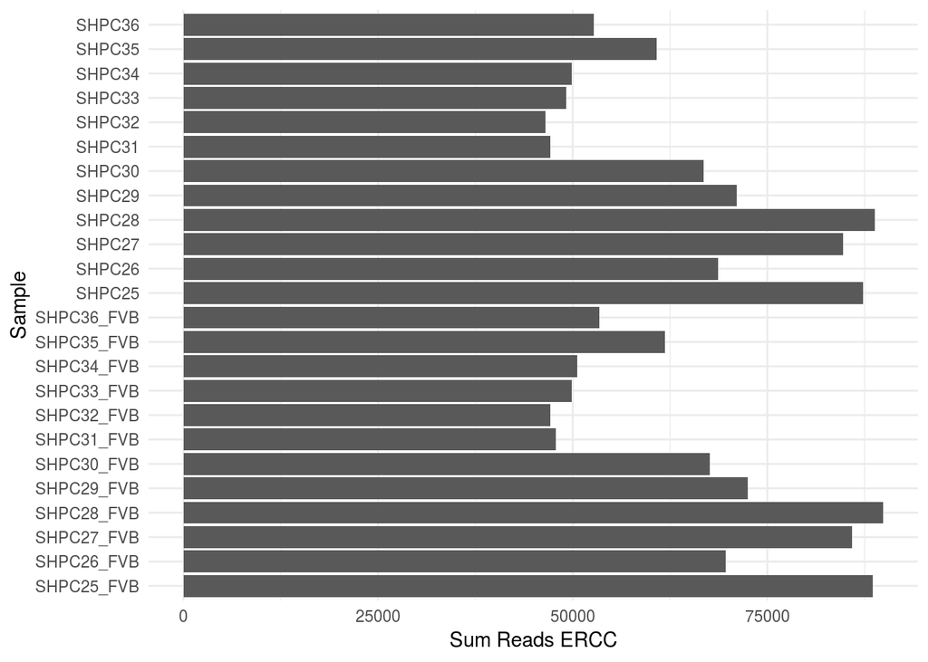

```r
samplestot=data.frame(rbind(samples,samples))
samplestot$mapping=c(rep("FVB",12),rep("genome",12))
row.names(samplestot)=names(dtot[,-grep("length",names(dtot))])
ddstot <- DESeqDataSetFromMatrix(dtot[,-grep("length",names(dtot))], colData = samplestot, design = ~ 1)
ddstot <- DESeq(ddstot)


ct_long=melt(counts(ddstot,norm=T), id.vars=c("Row.names"))

ct_long_ercc=ct_long %>%
    filter(grepl("ERCC",Var1))

p=ggplot(ct_long_ercc, aes(x=Var2, y=value, group=Var2)) +
geom_bar(stat="identity")+coord_flip()+ ylab("Sum Reads ERCC") + xlab("Sample")+
  theme_minimal()
p
```

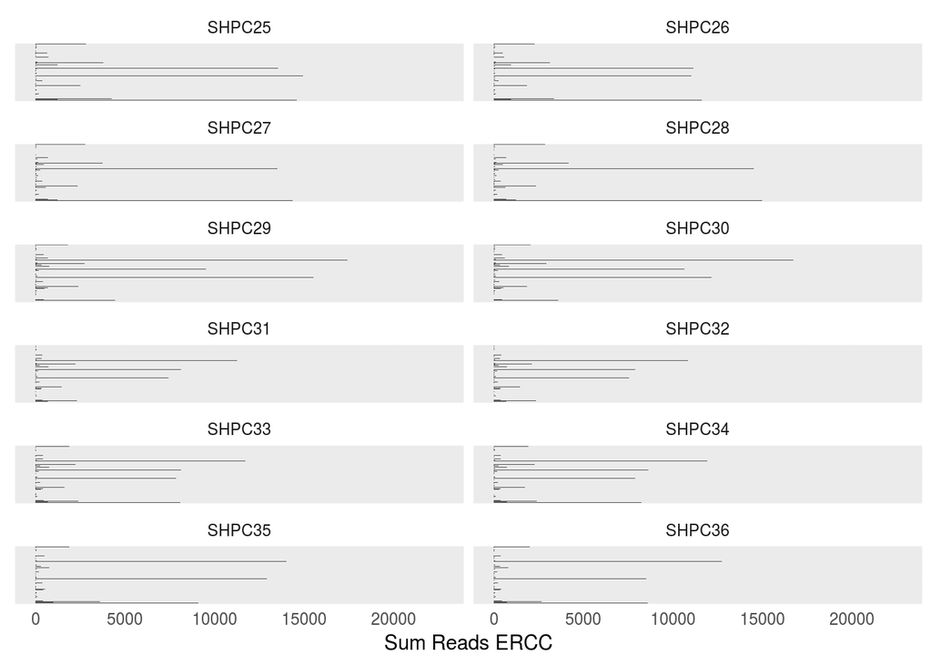

```r
ct_long_ercc_classique=ct_long %>%
    filter(grepl("ERCC",Var1)&!grepl("FVB",Var2))

p=ggplot(ct_long_ercc_classique, aes(x=Var1, y=value, group=Var2)) +
geom_bar(stat="identity")+coord_flip()+ ylab("Sum Reads ERCC") + xlab("Sample")+
  theme_minimal() + facet_wrap(~ Var2, ncol=2) +theme(axis.title.y=element_blank(),
        axis.text.y=element_blank(),
        axis.ticks.y=element_blank())
p
```

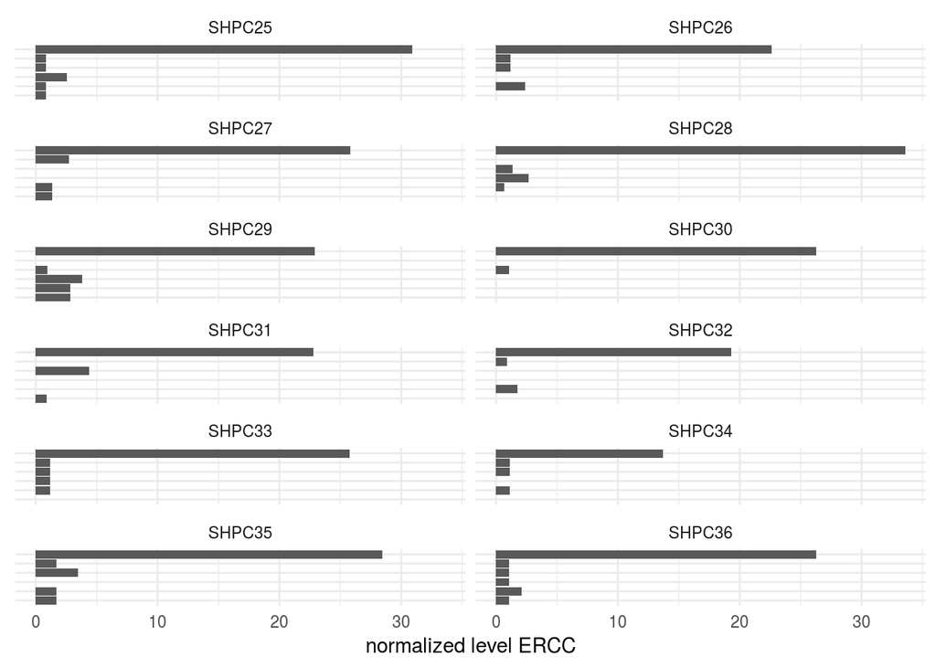

```r
ct_long_ercc_classique_part=ct_long %>%
    filter(grepl("ERCC-0001",Var1)&!grepl("FVB",Var2))

p=ggplot(ct_long_ercc_classique_part, aes(x=Var1, y=value, group=Var2)) +coord_flip()+
geom_bar(stat="identity")+ ylab("normalized level ERCC") + xlab("Sample")+
  theme_minimal() + facet_wrap(~ Var2, ncol=2) +theme(axis.title.y=element_blank(),
        axis.text.y=element_blank(),
        axis.ticks.y=element_blank())
p
```

# DESeq mapping artifact

- virer les gènes signif dans comptage FVB versus comptage C57BL6 -> me donner la table :

Attention les différents jeux de données n’ont pas le meme nombre de gènes (MUS1 = référence genome, FVB = FVB, tot = merge des deux). Les résultats du test pour dtot sont dans results_mappingartifact_allgenes.txt, la liste des gènes signif est dans liste_mappingartifact.txt

```r
knitr::kable(dim(dMUS1))
```

| x |
| --- |
| 32648 |
| 12 |

```r
knitr::kable(dim(dFVB1))
```

| x |
| --- |
| 29918 |
| 12 |

```r
knitr::kable(dim(dtot))
```

| x |
| --- |
| 19203 |
| 26 |

```r
ddstot <- DESeqDataSetFromMatrix(dtot[,-grep("length",names(dtot))], colData = samplestot, design = ~ mapping)
ddstot <- DESeq(ddstot)

resultsMapping <- results(ddstot)
knitr::kable(table(resultsMapping$padj < 0.05))
```

| Var1 | Freq |
| --- | --- |
| FALSE | 15206 |
| TRUE | 2897 |

```r
knitr::kable(table(resultsMapping$padj < 0.05,abs(dtot$length.x-dtot$length.y)>0.1*dtot$length.x))
```

|  | FALSE | TRUE |
| --- | --- | --- |
| FALSE | 12347 | 2859 |
| TRUE | 1129 | 1768 |

```r
c=counts(ddstot,norm=T)
cm=merge(resultsMapping,c,by.x=0,by.y=0)
row.names(cm)=row.names(resultsMapping)
write.table(file="results_mappingartifact_allgenes.txt",cm,row.names=T,sep="\t",quote=F)
write.table(file="liste_mappingartifact.txt",row.names(resultsMapping[resultsMapping$padj < 0.05&!is.na(resultsMapping$padj),]),row.names=F,col.names=F,sep="\t",quote=F)


write.table(file="liste_mappingartifact_length10per.txt",row.names(resultsMapping[resultsMapping$padj < 0.05&!is.na(resultsMapping$padj)&abs(dtot$length.x-dtot$length.y)>0.1*dtot$length.x,]),row.names=F,col.names=F,sep="\t",quote=F)
```

# Effet souche

Puis: sur gènes restants

## Sur Md+Mx

- gènes DE design Strain, prenant en compte la mâchoire -> me donner la table, si possible avec non seulement les gènes, la p-value, le fold change mais les comptes dans chaque échantillon

```r
listemappingartifact=row.names(resultsMapping[resultsMapping$padj < 0.05&!is.na(resultsMapping$padj)&abs(dtot$length.x-dtot$length.y)>0.1*dtot$length.x,])

ddsMus <- DESeqDataSetFromMatrix(dMUS1[(!row.names(dMUS1)%in%listemappingartifact),], colData = samples, design = ~ Jaw+Type)
ddsMus <- DESeq(ddsMus)
resultsMus <- results(ddsMus)
knitr::kable(table(resultsMus$padj < 0.05))
```

| Var1 | Freq |
| --- | --- |
| FALSE | 17346 |
| TRUE | 4473 |

```r
c=counts(ddsMus,norm=T)
cm=merge(resultsMus,c,by.x=0,by.y=0)
write.table(file="results_MusknowingStrain_allgenes.txt",cm,row.names=F,sep="\t",quote=F)
write.table(file="liste_MusknowingStrain.txt",row.names(resultsMus[resultsMus$padj < 0.05&!is.na(resultsMus$padj),]),row.names=F,col.names=F,sep="\t",quote=F)
```

## Sur Mx

- gènes DE Strain dans mx -> me donner la table, si possible avec non seulement les gènes, la p-value, le fold change mais les comptes dans chaque échantillon

```r
ddsMusMx <- DESeqDataSetFromMatrix(dMUS1[(!row.names(dMUS1)%in%listemappingartifact),samples$Jaw=="mX"], colData = samples[samples$Jaw=="mX",], design = ~ Type)
ddsMusMx <- DESeq(ddsMusMx)
resultsMusMx <- results(ddsMusMx)
knitr::kable(table(resultsMusMx$padj < 0.05))
```

| Var1 | Freq |
| --- | --- |
| FALSE | 17793 |
| TRUE | 2441 |

```r
c=counts(ddsMusMx,norm=T)
cm=merge(resultsMusMx,c,by.x=0,by.y=0)
write.table(file="results_MusMx_allgenes.txt",cm,row.names=T,sep="\t",quote=F)
write.table(file="liste_MusMx.txt",row.names(resultsMusMx[resultsMusMx$padj < 0.05&!is.na(resultsMusMx$padj),]),row.names=F,col.names=F,sep="\t",quote=F)
```

## Sur Md

- gènes DE Strain dans md -> me donner la table, si possible avec non seulement les gènes, la p-value, le fold change mais les comptes dans chaque échantillon

```r
ddsMusMd <- DESeqDataSetFromMatrix(dMUS1[(!row.names(dMUS1)%in%listemappingartifact),samples$Jaw=="mD"], colData = samples[samples$Jaw=="mD",], design = ~ Type)
ddsMusMd <- DESeq(ddsMusMd)
resultsMusMd <- results(ddsMusMd)
knitr::kable(table(resultsMusMd$padj < 0.05))
```

| Var1 | Freq |
| --- | --- |
| FALSE | 17642 |
| TRUE | 1698 |

```r
c=counts(ddsMusMd,norm=T)
cm=merge(resultsMusMd,c,by.x=0,by.y=0)
write.table(file="results_MusMd_allgenes.txt",cm,row.names=T,sep="\t",quote=F)
write.table(file="liste_MusMd.txt",row.names(resultsMusMx[resultsMusMd$padj < 0.05&!is.na(resultsMusMd$padj),]),row.names=F,col.names=F,sep="\t",quote=F)
```